# Ancient genomes document multiple waves of migration in Southeast Asian prehistory

Clara Font and Anna Casas

2026-03-18

## PART A:

**Where and why was the information collected?**

To get the libraries with evidence of authentic ancient DNA, the genome-wide data was generated using in-solution enrichment, yielding sequences from 18 individuals. Samples were analyzed from 5 ancient sites: Man Bac (Vietnam, Neolithic; 4100 to 3600 yr B.P.), Nui Nap (Vietnam, Bronze Age; 2100 to 1900 yr B.P.), Oakaie 1 (Myanmar, Late Neolithic/Bronze Age; 3200 to 2700 yr B.P.), Ban Chiang (Thailand, Late Neolithic through Iron Age; 3500 to 2400 yr B.P.), and Vat Komnou (Cambodia, Iron Age; 1900 to 1700 yr B.P.)

Data was collected to fill a research gap given that past population movements in Southeast Asia were poorly represented in ancient genetic studies. Also to trace ancient migrations (understand how and when ancient people moved, mixed, and spread agriculture and languages across the region) and to explain modern origins: discover how these ancient migrationss formed the diverse populations living in Southeast Asia nowadays.

**Which is the meaning of each variable?**

- Library ID: refers to the identifyier for each specific DNA library sequenced.
- Lab Indiv. ID: The lab’s unique ID for the specific ancient individual or skeleton.
- Skeletal codes: original name of the skeleton (when discovered by archeologists or whatever)
- UDG: I believe it stands for Uracil-DNA Glycosylase (chemical treatment from the lab)
- Skeletal element: which element of the skeleton was used for the DNA sequencing.
- Date (BCE/CE): approx. date from where the skeleton was alive (estimated age).
- Culture: historical group the individual belonged to.
- Location: where did the skeleton/individual live in.
- Country: country of origin of the skeleton.
- Extraction protocol: way of extraction of the skeleton (archeological matters)
- Library preparation: specific laboratory methods used to prepare the DNA I guess (specified in the paper)
- Equivalent mg bone powder used for library preparation: more laboratory methodology (quantities of bone powder to get the DNA)
- Shotgun raw sequences: total number of DNA reads the sequencing machine did. (all was sequenced - shotgun)
- Shotgun fraction raw sequences mapping to hg19: part of the shotgun raw sequences that belonged to a human individual.
- mtDNA sequences in alignment: how many of the DNA sequences were from the mitochondria (mt)
- mtDNA sequences aligning to target: how many of them were actually aligning to the target (also mitochondrial)
- Aligned mtDNA sequences remaining after deduping: similar to the other 2 (sequences aligning to target after methods in the laboratory).
- mtDNA coverage: how many times each part of the mithocondrial genome was sequenced.
- mtDNA median read length: average length of the DNA fragments/sequences (short numbers – old DNA is degraded).
- mtDNA fraction damaged in last base: ancient DNA degrades at the ends of the molecule (measure of the damage).
- mtDNA haplogroup: specific maternal lineage/ancestry group this individual belongs to.
- mtDNA match fraction: statistical check to ensure the DNA sequences are matching the human patterns.
- mtDNA match fraction 95% CI: same but with confidence interval
- Perform 1240k capture?: methodology to sequence ancient DNA (whether they used it or not)
- 1240k captured in pool?: wether this was captured in a genetic pool and the number of libraries in the corresponding pool.
- Used in analyses?: yes or no answer

**Do the variables have unit? Which one?**

Some variables have units of measurement, but not all of them. The variables that have units are: Date = years BCE/CE  
Equivalent bone powder used for library preparation = mg mtDNA coverage = X (fold) mtDNA median read length = bp

**Does the dataset have a long format?**

Yes, since it has 164 lines of data but only 18 unique individuals in total. There are many individuals that have lots of entries, for example individual with ID number I4011 has 22 entries.

**Write the code to:** **Read it into R**

```r
#install.packages("readxl")
library(readxl)

tables1 <- read_excel("/home/anna/Documentos/4t SEMESTRE/DV/PROJECT 1/aat3188_table_s1.xlsx", skip = 1)
tables1 <- head(tables1, -9)
View(tables1)
```

**Reshape the data if necessary into long format**

By now we don’t think it is necessary since this format should be just fine to plot everything. If it didn’t work, we would consider changing the format later on.

**Check the variable classes and update them if necessary**

```r
#str(tables1)
tables1$`Shotgun raw sequences` <- as.numeric(tables1$`Shotgun raw sequences`)
tables1$`Shotgun fraction raw sequences mapping to hg19` <- as.numeric(tables1$`Shotgun fraction raw sequences mapping to hg19`)
tables1$`mtDNA sequences in alignment` <- as.numeric(tables1$`mtDNA sequences in alignment`)
tables1$`mtDNA sequences aligning to target` <- as.numeric(tables1$`mtDNA sequences aligning to target`)
tables1$`Aligned mtDNA sequences remaining after deduping` <- as.numeric(tables1$`Aligned mtDNA sequences remaining after deduping`)
tables1$`mtDNA coverage` <- as.numeric(tables1$`mtDNA coverage`)
tables1$`mtDNA median read length` <- as.numeric(tables1$`mtDNA median read length`)
tables1$`mtDNA fraction damaged in last base` <- as.numeric(tables1$`mtDNA fraction damaged in last base`)
tables1$`mtDNA match fraction` <- as.numeric(tables1$`mtDNA match fraction`)
```

## PART B

**Graph 1: Geographical distribution of the samples**

Understanding the geographical origin of the samples is an essential step to evaluate the territorial part of this study and to detect potential sampling biases. For this purpose, we have exposed the distribution of the extracted libraries across the study region.

Our initial hypothesis is that the collection effort in Southeast Asia is not homogeneous; we expect to observe a higher concentration of samples coming from Vietnam or Thailand due to a higher prevalence of the studied matter.

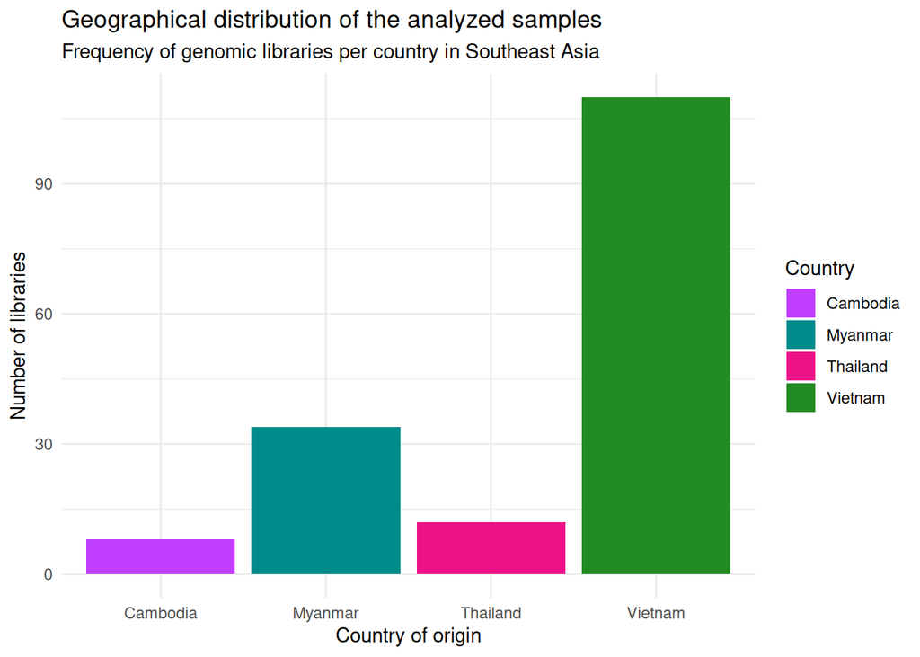

```r
library(ggplot2)
graph1 <- ggplot(tables1, aes(x = Country, fill = Country)) +
          geom_bar() +
          scale_fill_manual(values = c("Vietnam" = "forestgreen",
                                       "Thailand" = "deeppink2",
                                       "Cambodia" = "darkorchid1",
                                       "Myanmar" = "cyan4")) +
          theme_minimal() +
          labs(title = "Geographical distribution of the analyzed samples",
              subtitle = "Frequency of genomic libraries per country in Southeast Asia",
              x = "Country of origin",
              y = "Number of libraries")
print(graph1)
```

The visual analysis of the geographical distribution reveals a clear difference in the origin of the libraries. As observed in the plot, Vietnam has the higher the extraction level, contributing a majority proportion of the data set. In contrast, Cambodia and Thailand present a low number of collected samples.

**Graph 2: Median length of the archaeological rests** In this second plot, we analyze a continuous variable: the mtDNA median read length. It measures the average size of the sequenced DNA fragments in base pairs (bp). We created this histogram to evaluate the physical preservation and fragmentation level of the genetic material extracted from the samples.

Since we are working with archaeological remains that are thousands of years old (they have suffered damage), our hypothesis is that the DNA will be highly degraded. Therefore, we expect the histogram to show a distribution concentrated at the lower end, indicating that the majority of the recovered DNA fragments are extremely short.

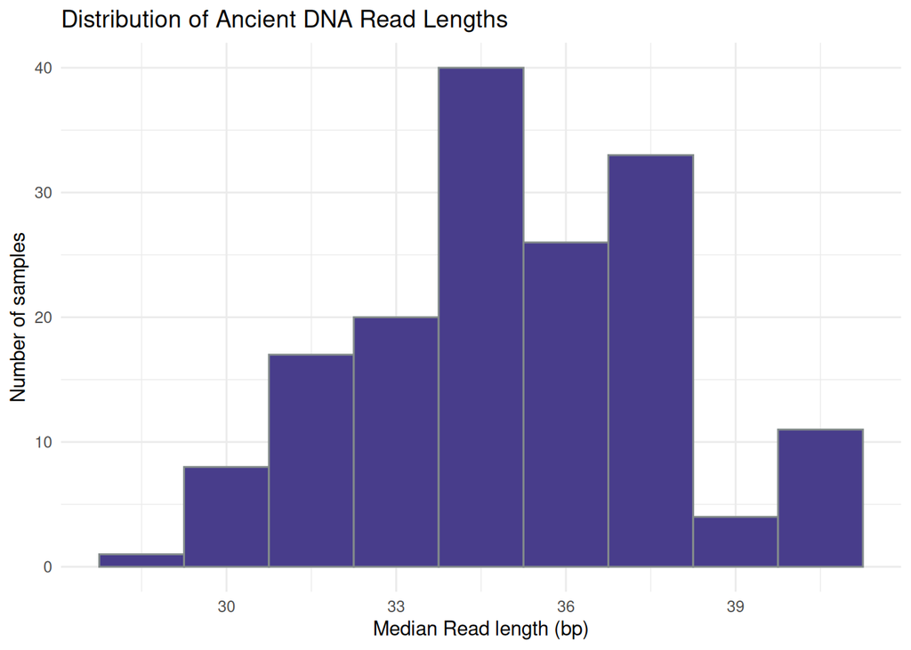

```r
graph2 <- ggplot(tables1, aes(x = `mtDNA median read length`)) +
  geom_histogram(fill = "darkslateblue", color = "azure4", binwidth = 1.5, na.rm = TRUE) +
  theme_minimal() +
  labs(title = "Distribution of Ancient DNA Read Lengths",
       x = "Median Read length (bp)",
       y = "Number of samples")

print(graph2)
```

The histogram coincides with our hypothesis. The distribution is clustered, the majority of the samples have a median read length between 30 and 45 base pairs. There are no long DNA sequences.

We can conclude that this extreme fragmentation is typical in ancient DNA caused by the course of time. The results demonstrate that the genetic material has been thorugh natural degradation, and the absence of long DNA suggests that the samples do not have actual human DNA contamination, proving reliability to the study.

**Graph 3: Is there a relationship between the quality of the DNA fragments and the utility of those?**

We want to summarize the data by exploring the relationship between two variables. To do this, we use a boxplot, which is ideal for comparing the distribution, median, and spread of a continuous variable throughh different groups (in this case, discrete). We’ve decided to compare the discrete variable: “Used in analyses?” with the continuous variable: “mtDNA match fraction.”

Our hypothesis is that there is a direct positive relationship between DNA quality the authenticity and purity of the sample andd also its utility. Therefore, we expect the samples named as “Yes” (used in analyses) to result a significantly higher and more clustered median mtDNA match fraction than those labeled as “No” (rejected samples).

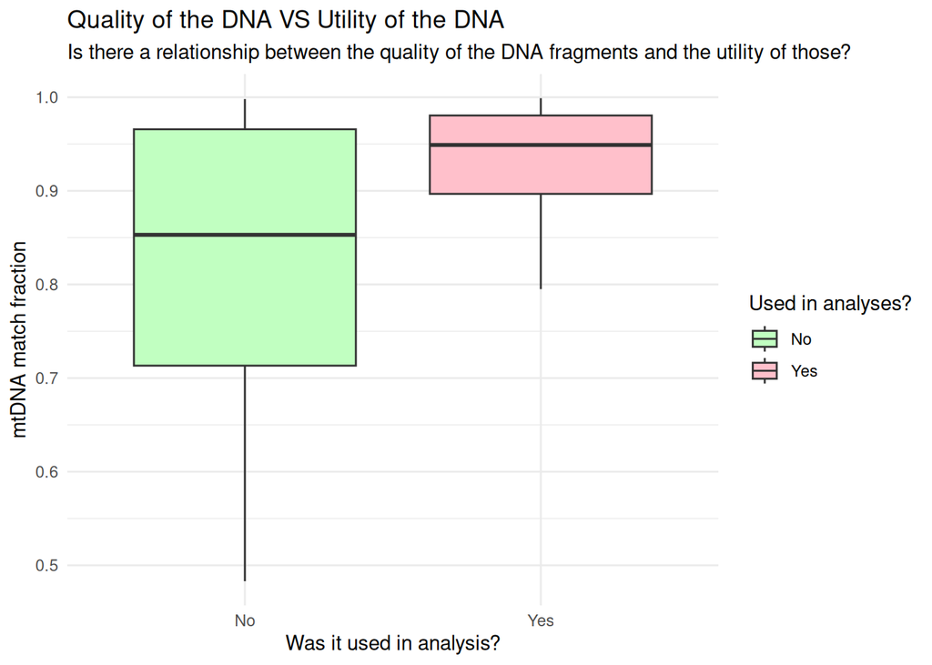

```r
tables1$`Used in analyses?`[tables1$`Used in analyses?` == "No^"] <- "No"
graph3 <- ggplot(tables1, aes(x = `Used in analyses?`, y = `mtDNA match fraction`, fill = `Used in analyses?`)) +
                geom_boxplot(outlier.color = "black", na.rm = TRUE) +
                scale_fill_manual(values = c("No" = "darkseagreen1",
                                             "Yes" = "pink")) +
                theme_minimal() +
                labs(title = "Quality of the DNA VS Utility of the DNA",
                     subtitle = "Is there a relationship between the quality of the DNA fragments and the utility of those?",
                     x = "Was it used in analysis?",
                     y = "mtDNA match fraction")

print(graph3)
```

The boxplot strongly validates our hypothesis, revealing a difference between the categories. As seeen in the graph, the “Yes” category shows a high median box near the top of the Y-axis (closer to 1), this indicates that these sequences highly match the expected human DNA patterns with minimal contamination. In contrast, the rejected samples (“No”) generally show much lower or highly variable match fractions, causing their boxes to appear in a lower part of the axis.

The visual evidence is very helpful to make conclusions: the mtDNA match fraction is a key factor for sample utility. A sample requires a high proportion of authentic, matching DNA to be considered reliable and valid for the study.

**Bonus: Is there a relationship between DNA fragment length and the amount of usable sequences between different countries?**

This graph has been done just for curiosity and to test facet_grid.

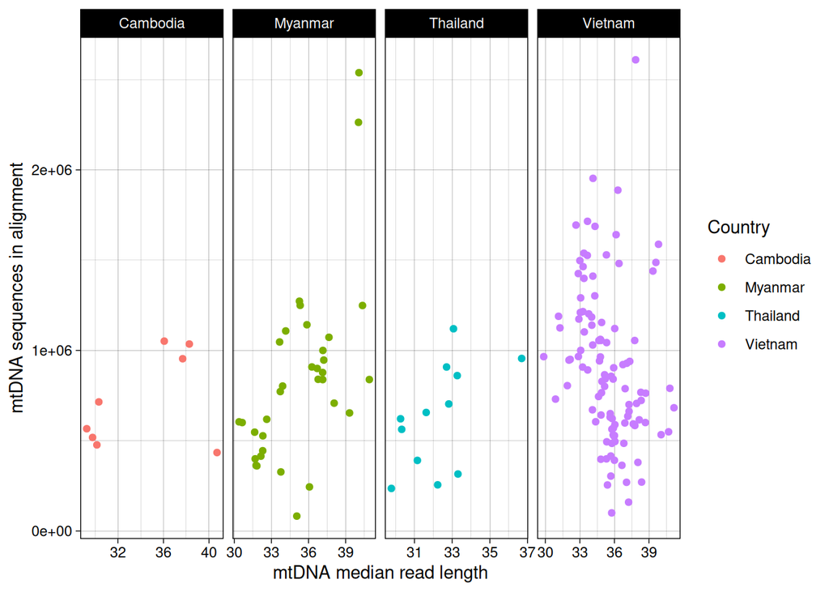

```r
graph2<- ggplot(data=tables1, aes(x= `mtDNA median read length`, y=`mtDNA sequences in alignment`, fill= Country, color=Country)) + geom_jitter(na.rm = TRUE) + scale_fill_manual(values = c("Vietnam" = "forestgreen",
                                       "Thailand" = "deeppink2",
                                       "Cambodia" = "darkorchid1",
                                       "Myanmar" = "cyan4"))  + facet_grid(~ Country, scales="free_x") +
  labs(x = "mtDNA median read length", y = "mtDNA sequences in alignment")  + theme_linedraw()
graph2
```

Using this graph, and separating the data by country we have seen clear geographical differences in sample success. Some countries (such as Vietnam, which has highly relevant Neolithic sites like Man Bac) display a dense cluster of points with high sequence yields. On the other hand, other regions might show lower yields or shorter fragment lengths, perhaps due to different environmental conditions for DNA survival. This shows not only the quality of the individual samples but also the broad archaeological challenges of extracting ancient DNA in Southeast Asia, that is the center of the whole study.